# Mediation with svyset data

Josh Errickson

Mediation models in Stata are fit with the `sem` command. `sem` does not support `svyset` data, so instead you use `gsem` (e.g. `svy: gsem …`). However, `gsem` does not support `estat teffects` which calculates direct, indirect and total effects.

This document shows how to manually calculate these effects using `nlcom`.

Note that this is a case where all variables are continuous and all models are linear - we are only using `gsem` for it’s support of `svy:`, not it’s support of GLMs. Indirect effects are a more complicated topic in those models which we do not address here. Additionally, we’ll trust Stata to compute standard errors rather than getting into any sticky issues of bootstrapping.

# Standard Mediation

First, let’s estimate the direct, indirect and total effects without the use of the survey design to show equivalence.

```
. webuse gsem_multmed
(Fictional job-performance data)
```

The model we’ll be fitting is

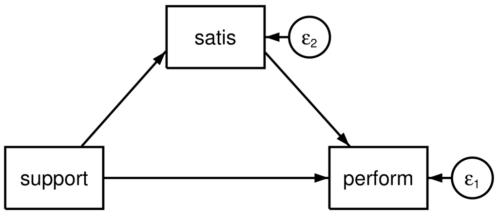

Here, “satis” is a potential mediator between “support” and “perform”. The direct effect is the arrow between “support” and “perform”, the indirect effect is the arrows from “support” to “perform” which passes through “satis”, and the total effect is the sum of the direct and indirect effects.

```
. sem (perform <- satis support) (satis <- support)

Endogenous variables

Observed:  perform satis

Exogenous variables

Observed:  support

Fitting target model:

Iteration 0:   log likelihood = -3779.9224
Iteration 1:   log likelihood = -3779.9224

Structural equation model                       Number of obs     =      1,500
Estimation method  = ml
Log likelihood     = -3779.9224

------------------------------------------------------------------------------
             |                 OIM
             |      Coef.   Std. Err.      z    P>|z|     [95% Conf. Interval]
-------------+----------------------------------------------------------------
Structural   |
  perform    |
       satis |   .8984401   .0251903    35.67   0.000      .849068    .9478123
     support |   .6161077   .0303143    20.32   0.000     .5566927    .6755227
       _cons |   4.981054   .0150589   330.77   0.000     4.951539    5.010569
  -----------+----------------------------------------------------------------
  satis      |
     support |   .2288945   .0305047     7.50   0.000     .1691064    .2886826
       _cons |    .019262   .0154273     1.25   0.212    -.0109749    .0494989
-------------+----------------------------------------------------------------
var(e.perf~m)|   .3397087   .0124044                      .3162461     .364912
 var(e.satis)|   .3569007   .0130322                      .3322507    .3833795
------------------------------------------------------------------------------
LR test of model vs. saturated: chi2(0)   =      0.00, Prob > chi2 =      .
```

The direct, indirect and total effects can be estimated via `estat teffects`.

```
. estat teffects


Direct effects
------------------------------------------------------------------------------
             |                 OIM
             |      Coef.   Std. Err.      z    P>|z|     [95% Conf. Interval]
-------------+----------------------------------------------------------------
Structural   |
  perform    |
       satis |   .8984401   .0251903    35.67   0.000      .849068    .9478123
     support |   .6161077   .0303143    20.32   0.000     .5566927    .6755227
  -----------+----------------------------------------------------------------
  satis      |
     support |   .2288945   .0305047     7.50   0.000     .1691064    .2886826
------------------------------------------------------------------------------


Indirect effects
------------------------------------------------------------------------------
             |                 OIM
             |      Coef.   Std. Err.      z    P>|z|     [95% Conf. Interval]
-------------+----------------------------------------------------------------
Structural   |
  perform    |
       satis |          0  (no path)
     support |    .205648   .0280066     7.34   0.000      .150756      .26054
  -----------+----------------------------------------------------------------
  satis      |
     support |          0  (no path)
------------------------------------------------------------------------------


Total effects
------------------------------------------------------------------------------
             |                 OIM
             |      Coef.   Std. Err.      z    P>|z|     [95% Conf. Interval]
-------------+----------------------------------------------------------------
Structural   |
  perform    |
       satis |   .8984401   .0251903    35.67   0.000      .849068    .9478123
     support |   .8217557   .0404579    20.31   0.000     .7424597    .9010516
  -----------+----------------------------------------------------------------
  satis      |
     support |   .2288945   .0305047     7.50   0.000     .1691064    .2886826
------------------------------------------------------------------------------
```

Let’s calculate them manually. First we’ll re-display the SEM results with the `coeflegend` to obtain the names to access the coefficients.

```
. sem, coeflegend

Structural equation model                       Number of obs     =      1,500
Estimation method  = ml
Log likelihood     = -3779.9224

------------------------------------------------------------------------------
             |      Coef.  Legend
-------------+----------------------------------------------------------------
Structural   |
  perform    |
       satis |   .8984401  _b[perform:satis]
     support |   .6161077  _b[perform:support]
       _cons |   4.981054  _b[perform:_cons]
  -----------+----------------------------------------------------------------
  satis      |
     support |   .2288945  _b[satis:support]
       _cons |    .019262  _b[satis:_cons]
-------------+----------------------------------------------------------------
var(e.perf~m)|   .3397087  _b[/var(e.perform)]
 var(e.satis)|   .3569007  _b[/var(e.satis)]
------------------------------------------------------------------------------
LR test of model vs. saturated: chi2(0)   =      0.00, Prob > chi2 =      .
```

The main effects are directly from the model, but for completeness let’s obtain it.

```
. estat teffects, noindirect nototal


Direct effects
------------------------------------------------------------------------------
             |                 OIM
             |      Coef.   Std. Err.      z    P>|z|     [95% Conf. Interval]
-------------+----------------------------------------------------------------
Structural   |
  perform    |
       satis |   .8984401   .0251903    35.67   0.000      .849068    .9478123
     support |   .6161077   .0303143    20.32   0.000     .5566927    .6755227
  -----------+----------------------------------------------------------------
  satis      |
     support |   .2288945   .0305047     7.50   0.000     .1691064    .2886826
------------------------------------------------------------------------------

. nlcom _b[perform:support]

       _nl_1:  _b[perform:support]

------------------------------------------------------------------------------
             |      Coef.   Std. Err.      z    P>|z|     [95% Conf. Interval]
-------------+----------------------------------------------------------------
       _nl_1 |   .6161077   .0303143    20.32   0.000     .5566927    .6755227
------------------------------------------------------------------------------
```

For the indirect effect, we’ll simply multiply the path from “support” to “satis” and from “satis” to “perform”.

```
. estat teffects, nodirect nototal


Indirect effects
------------------------------------------------------------------------------
             |                 OIM
             |      Coef.   Std. Err.      z    P>|z|     [95% Conf. Interval]
-------------+----------------------------------------------------------------
Structural   |
  perform    |
       satis |          0  (no path)
     support |    .205648   .0280066     7.34   0.000      .150756      .26054
  -----------+----------------------------------------------------------------
  satis      |
     support |          0  (no path)
------------------------------------------------------------------------------

. nlcom _b[perform:satis]*_b[satis:support]

       _nl_1:  _b[perform:satis]*_b[satis:support]

------------------------------------------------------------------------------
             |      Coef.   Std. Err.      z    P>|z|     [95% Conf. Interval]
-------------+----------------------------------------------------------------
       _nl_1 |    .205648   .0280066     7.34   0.000      .150756      .26054
------------------------------------------------------------------------------
```

```
. estat teffects, nodirect noindirect


Total effects
------------------------------------------------------------------------------
             |                 OIM
             |      Coef.   Std. Err.      z    P>|z|     [95% Conf. Interval]
-------------+----------------------------------------------------------------
Structural   |
  perform    |
       satis |   .8984401   .0251903    35.67   0.000      .849068    .9478123
     support |   .8217557   .0404579    20.31   0.000     .7424597    .9010516
  -----------+----------------------------------------------------------------
  satis      |
     support |   .2288945   .0305047     7.50   0.000     .1691064    .2886826
------------------------------------------------------------------------------

. nlcom _b[perform:satis]*_b[satis:support] + _b[perform:support]

       _nl_1:  _b[perform:satis]*_b[satis:support] + _b[perform:support]

------------------------------------------------------------------------------
             |      Coef.   Std. Err.      z    P>|z|     [95% Conf. Interval]
-------------+----------------------------------------------------------------
       _nl_1 |   .8217557   .0404579    20.31   0.000     .7424597    .9010516
------------------------------------------------------------------------------
```

# With survey data

We’ll reproduce the above results with survey set data. The actually `svyset` here is nonsense, this test data is not actual survey data.

```
. svyset branch [pweight = perform]

      pweight: perform
          VCE: linearized
  Single unit: missing
     Strata 1: <one>
         SU 1: branch
        FPC 1: <zero>
```

To use the `svy` prefix, we switch from `sem` to `gsem`.

```
. svy: gsem (perform <- satis support) (satis <- support)
(running gsem on estimation sample)

Survey: Generalized structural equation model

Number of strata   =         1                  Number of obs     =      1,500
Number of PSUs     =        75                  Population size   =  7,507.976
                                                Design df         =         74

Response       : perform
Family         : Gaussian
Link           : identity

Response       : satis
Family         : Gaussian
Link           : identity

------------------------------------------------------------------------------
             |             Linearized
             |      Coef.   Std. Err.      t    P>|t|     [95% Conf. Interval]
-------------+----------------------------------------------------------------
perform      |
       satis |   .8768337   .0478296    18.33   0.000      .781531    .9721363
     support |   .6105411   .0276199    22.11   0.000     .5555072     .665575
       _cons |   5.051254   .0414936   121.74   0.000     4.968576    5.133932
-------------+----------------------------------------------------------------
satis        |
     support |    .212986   .0261195     8.15   0.000     .1609418    .2650301
       _cons |   .0841272   .0583215     1.44   0.153     -.032081    .2003353
-------------+----------------------------------------------------------------
var(e.perf~m)|   .3284831   .0241911                      .2836511    .3804009
 var(e.satis)|   .3570689   .0353162                      .2931998    .4348508
------------------------------------------------------------------------------
```

Finally, all three effects can be calculated via the same `nlcom` commands.

```
. * main effect
. nlcom _b[perform:support]

       _nl_1:  _b[perform:support]

------------------------------------------------------------------------------
             |      Coef.   Std. Err.      z    P>|z|     [95% Conf. Interval]
-------------+----------------------------------------------------------------
       _nl_1 |   .6105411   .0276199    22.11   0.000      .556407    .6646751
------------------------------------------------------------------------------

.
. * Indirect effect
. nlcom _b[perform:satis]*_b[satis:support]

       _nl_1:  _b[perform:satis]*_b[satis:support]

------------------------------------------------------------------------------
             |      Coef.   Std. Err.      z    P>|z|     [95% Conf. Interval]
-------------+----------------------------------------------------------------
       _nl_1 |   .1867533   .0253151     7.38   0.000     .1371366    .2363699
------------------------------------------------------------------------------

.
. * Total effect
. nlcom _b[perform:satis]*_b[satis:support] + _b[perform:support]

       _nl_1:  _b[perform:satis]*_b[satis:support] + _b[perform:support]

------------------------------------------------------------------------------
             |      Coef.   Std. Err.      z    P>|z|     [95% Conf. Interval]
-------------+----------------------------------------------------------------
       _nl_1 |   .7972943   .0308642    25.83   0.000     .7368017     .857787
------------------------------------------------------------------------------

.
```